# GAM and NN in R

Zifeng Zhao

week 03 session 01

In this lab, we will practice implementing Polynomial regression, Generalized Additive Model (GAM) and Neural Network (NN) in `R`.

### 1.1 Data Preparation

Let’s read in the data stored in `UsedCar.csv` and log transform the dependent variable Price to correct the right-skewness. Let’s further do a 80%-20% training-test split from the very beginning. We use the `set.seed()` function in `R` to control the randomness of the training-test split.

```r
rm(list=ls())
set.seed(7)
total_data <- read.csv("./UsedCar.csv", header=T, stringsAsFactors=T)
total_obs <- dim(total_data)[1]
total_data$Log_price <- log(total_data$Price+1)
## Data Partition: Training v.s. Test split
train_data_indices <- sample(1:total_obs, 0.8*total_obs)
train_data <- total_data[train_data_indices,]
test_data <- total_data[-train_data_indices,]
train_obs <- dim(train_data)[1]
```

### 1.2 Polynomial Regression

We first build a linear regression model with predictors `Age + Mileage + Fuel_Type + HP + Weight` and name it `lm1`. Based on previous data visualization, we further build a polynomial regression that involves second order polynomial terms for predictors `Age`, `Mileage` and `Weight`, and we store the model in `lm1_poly`.

```r
lm1 <- lm(Log_price~Age+Mileage+Fuel_Type+HP+Weight, data=train_data)
lm1_poly <- lm(Log_price~Age+I(Age^2)+Mileage+I(Mileage^2)+Fuel_Type+HP+
                   Weight+I(Weight^2), data=train_data)
```

Let’s evaluate the prediction performance of `lm1` and `lm1_poly` on the test data and see if the additional polynomial terms help improve the prediction accuracy.

```r
library(forecast)
# Model deployment
lm1_pred <- exp(predict(lm1, newdata=test_data))-1
lm1_poly_pred <- exp(predict(lm1_poly, newdata=test_data))-1
# Test data error
accuracy(lm1_pred, test_data$Price) # good fit as well but more complicated and difficult to explain than lm_bwd_pred
```

```
##                ME     RMSE      MAE       MPE     MAPE
## Test set 122.2128 1328.321 981.1436 -0.667698 9.796012
```

```r
accuracy(lm1_poly_pred, test_data$Price) # second simple model (good fit)
```

```
##                ME     RMSE     MAE        MPE     MAPE
## Test set 103.7877 1287.924 955.495 -0.7185982 9.579281
```

### 1.3 Generalized Additive Model

Note that the additional polynomial terms do help improve the prediction accuracy to some degree. We now build a GAM with predictors `Age + Mileage + Fuel_Type + HP + Weight`. We specify splines with degree-of-freedom=4 for predictors `Age`, `Mileage` and `Weight`, and we store the model in `gam1`. We can use `plot()` function to visualize the estimated coefficients and splines for each predictor. Note that we can still interpret the estimated model `gam1` due to the additivity of GAM.

```r
library(gam)
```

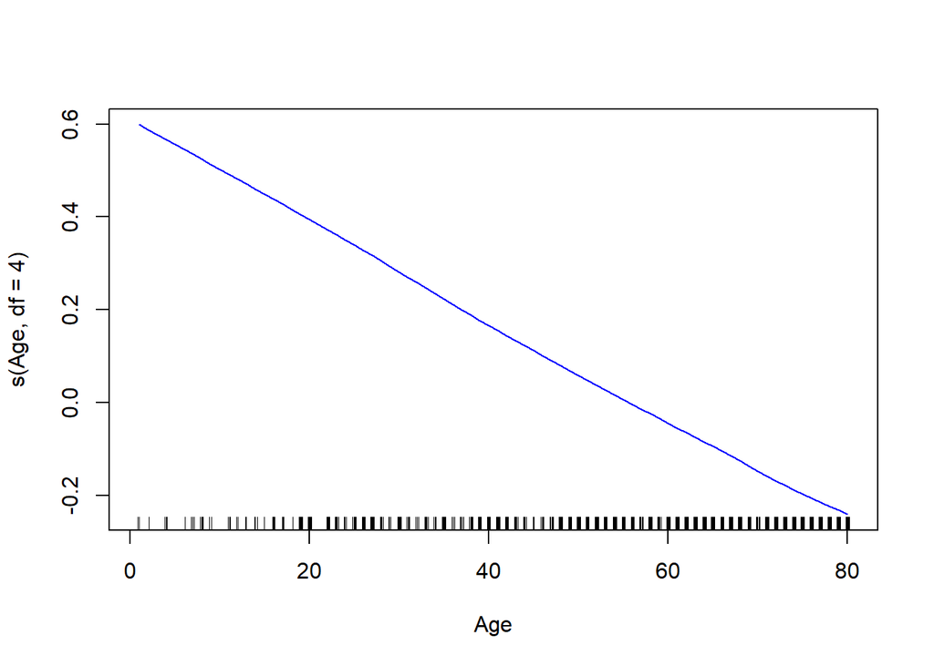

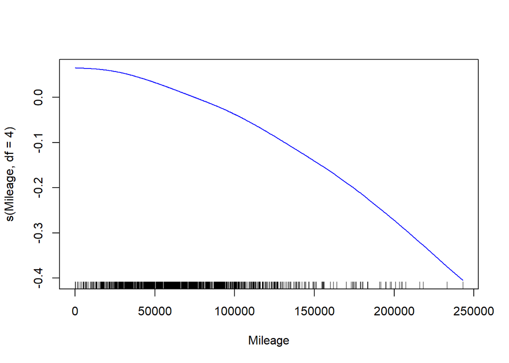

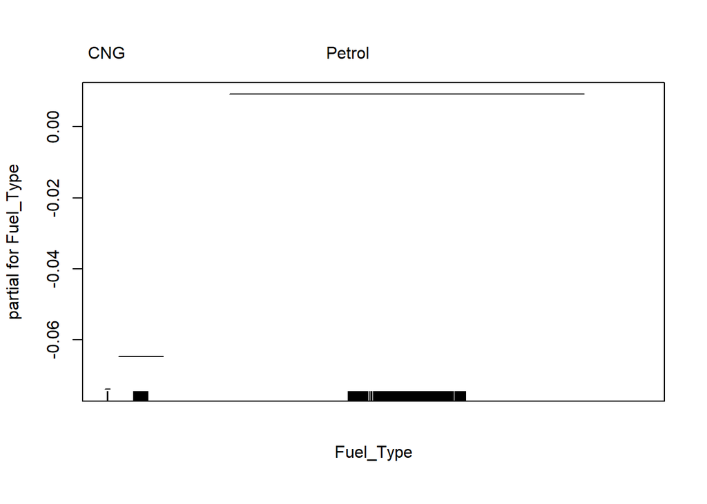

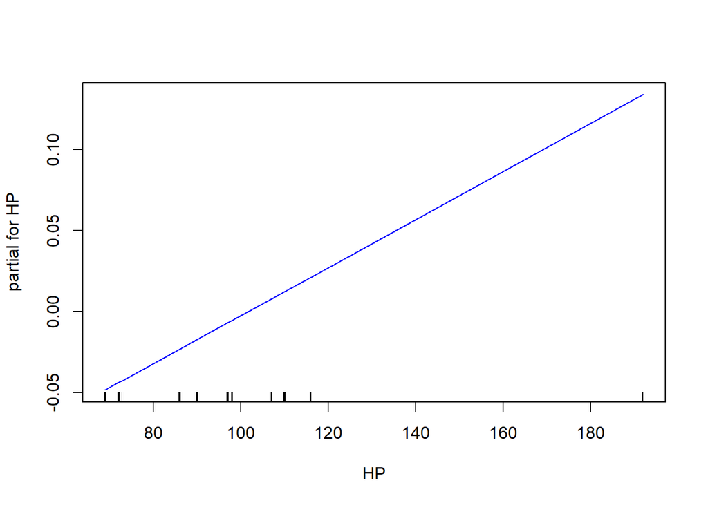

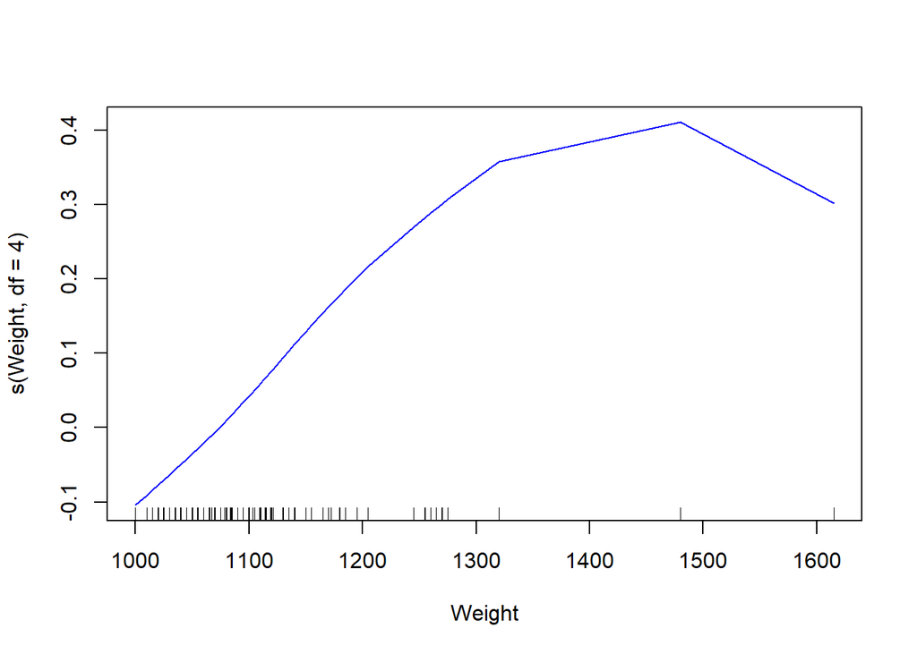

```r
## Fit a GAM
gam1 <- gam(Log_price~s(Age,df=4)+s(Mileage,df=4)+Fuel_Type+HP+s(Weight,df=4),
                data=train_data)
plot(gam1, col='blue') # rugplot=T gives the incidents along the x-axis, but uses jittering for tiebreaker
```

```r
print(gam1$coefficients)
```

```
##        (Intercept)     s(Age, df = 4) s(Mileage, df = 4)    Fuel_TypeDiesel
##       8.243997e+00      -1.063687e-02      -1.581973e-06       9.250621e-03
##    Fuel_TypePetrol                 HP  s(Weight, df = 4)
##       8.313269e-02       1.480108e-03       1.369279e-03
```

```r
print(summary(gam1))
```

```
##
## Call: gam(formula = Log_price ~ s(Age, df = 4) + s(Mileage, df = 4) +
##     Fuel_Type + HP + s(Weight, df = 4), data = train_data)
## Deviance Residuals:
##       Min        1Q    Median        3Q       Max
## -0.676601 -0.059734  0.002838  0.071796  0.445463
##
## (Dispersion Parameter for gaussian family taken to be 0.0119)
##
##     Null Deviance: 99.1032 on 1147 degrees of freedom
## Residual Deviance: 13.4954 on 1132 degrees of freedom
## AIC: -1809.174
##
## Number of Local Scoring Iterations: NA
##
## Anova for Parametric Effects
##                      Df Sum Sq Mean Sq   F value Pr(>F)
## s(Age, df = 4)        1 78.948  78.948 6622.1690 <2e-16 ***
## s(Mileage, df = 4)    1  3.433   3.433  287.9328 <2e-16 ***
## Fuel_Type             2  0.031   0.016    1.3211 0.2673
## HP                    1  2.343   2.343  196.5076 <2e-16 ***
## s(Weight, df = 4)     1  1.959   1.959  164.3401 <2e-16 ***
## Residuals          1132 13.495   0.012
## ---
## Signif. codes:  0 '***' 0.001 '**' 0.01 '*' 0.05 '.' 0.1 ' ' 1
##
## Anova for Nonparametric Effects
##                    Npar Df  Npar F     Pr(F)
## (Intercept)
## s(Age, df = 4)           3  2.5207 0.0565350 .
## s(Mileage, df = 4)       3  6.8611 0.0001398 ***
## Fuel_Type
## HP
## s(Weight, df = 4)        3 10.3188 1.056e-06 ***
## ---
## Signif. codes:  0 '***' 0.001 '**' 0.01 '*' 0.05 '.' 0.1 ' ' 1
```

Let’s evaluate the out-of-sample prediction performance of `gam1`. Note that GAM indeed further improves the prediction accuracy.

```r
## Model evaluation on Test data
gam1_pred <- exp(predict(gam1, newdata=test_data))-1
accuracy(gam1_pred, test_data$Price)
```

```
##                ME    RMSE      MAE        MPE     MAPE
## Test set 92.93126 1266.39 930.6484 -0.7810658 9.441454
```

### 1.4 Neural Networks

We now build an NN with predictors `Age + Mileage + Fuel_Type + HP + Weight`, which allows both non-linearity and interaction among predictors. Note that the implementation of NN in R is **complicated** and significantly different from linear regression and GAM. It requires more manual configuration.

First of all, NN requires reformatted training data and test data. We first need to reformat the training data and construct a data frame with categorical predictors being represented as dummy variables and store it in `x_train_nn`. We then standardize all predictors $X$ in the data frame `x_train_nn` and combine the data frame with the dependent variable.

```r
library(neuralnet)
# generate a data frame with categorical predictors being represented as dummy variables
x_train_nn <- model.matrix(~Age+Mileage+Fuel_Type+HP+Weight, data=train_data)[,-1]
# standardization
x_mean <- apply(x_train_nn, 2, mean)
x_sd <- apply(x_train_nn, 2, sd)
x_train_nn <- scale(x_train_nn, center=x_mean, scale=x_sd)

# combine with dependent variable Log_price
x_train_nn <- cbind.data.frame(train_data$Log_price, x_train_nn)
colnames(x_train_nn)[1] <- 'Log_price'
```

```r
# generate and standardize the data frame for the test data as well
x_test_nn <- model.matrix(~Age+Mileage+Fuel_Type+HP+Weight, data=test_data)[,-1]
# standardization
x_test_nn <- scale(x_test_nn, center=x_mean, scale=x_sd)
```

We now build an NN with all predictors available and store it in `nn1`. For the architecture of `nn1`, let’s have two hidden layers with 6 hidden units in the first layer and 4 hidden units in the second layer and keep the activation function as sigmoid. Note that there is randomness in the training of NN due to the random initialization of the optimization. Thus we use `set.seed()` to control the randomness and ensure reproducibility. We can use `plot()` function to visualize the estimated NN, however, it is difficult to interpret the estimated model.

```r
set.seed(7)
nn1 <- neuralnet(Log_price~Age+Mileage+Fuel_TypeDiesel+Fuel_TypePetrol+HP+Weight, data=x_train_nn, hidden=c(6,4))
# plot(nn1)
nn1$act.fct # sigmoid function
```

```
## function (x)
## {
##     1/(1 + exp(-x))
## }
## <bytecode: 0x000000001f4c25d8>
## <environment: 0x000000001f4c1ce0>
## attr(,"type")
## [1] "logistic"
```

Let’s evaluate the out-of-sample prediction performance of `nn1`. Note that NN further improves the prediction accuracy.

```r
nn_pred <- exp(predict(nn1, newdata=x_test_nn)[,1])-1
accuracy(nn_pred, test_data$Price)
```

```
##                ME     RMSE      MAE        MPE     MAPE
## Test set 98.05046 1192.998 871.2584 -0.4159741 8.978626
```

## 2. In-class Exercise: Analysis based on original-scale Price

Let’s practice building, linear regression, polynomial regression, GAM and NN for predicting the original-scale Price with predictors `Age + Mileage + Fuel_Type + HP + Weight`. We store the estimated models in `R` object `lm2`, `lm2_poly`, `gam2` and `nn2` respectively.

- lm2: `Price~Age+Mileage+Fuel_Type+HP+Weight`
- lm2_poly: `Price~Age+I(Age^2)+Mileage+I(Mileage^2)+Fuel_Type+HP+Weight+I(Weight^2)`
- gam2: `Price~s(Age,df=4)+s(Mileage,df=4)+Fuel_Type+HP+s(Weight,df=4)`
- nn2: `St_Price~Age+Mileage+Fuel_TypeDiesel+Fuel_TypePetrol+HP+Weight`

```r
lm2 <- lm(Price~Age+Mileage+Fuel_Type+HP+Weight, data=train_data)
lm2_poly <- lm(Price~Age+I(Age^2)+Mileage+I(Mileage^2)+Fuel_Type+HP+Weight+I(Weight^2), data=train_data)
gam2 <- gam(Price~s(Age,df=4)+s(Mileage,df=4)+Fuel_Type+HP+s(Weight,df=4), data=train_data)
```

Note that besides the predictors $X$, we need to further standardize the original-scale dependent variable $Y$ by its maximum value in the training data.

```r
# Standardize the predictors (training data)
x_train_nn <- model.matrix(~Age+Mileage+Fuel_Type+HP+Weight, data=train_data)[,-1]
x_mean <- apply(x_train_nn, 2, mean)
x_sd <- apply(x_train_nn, 2, sd)
x_train_nn <- scale(x_train_nn, center=x_mean, scale=x_sd)

# Standardize the original scale dependent variable (training data)
y_max <- max(train_data$Price)
x_train_nn <- cbind.data.frame(train_data$Price/y_max, x_train_nn)
colnames(x_train_nn)[1] <- 'St_Price'

# Standardize the predictors (test data)
x_test_nn <- model.matrix(~Age+Mileage+Fuel_Type+HP+Weight, data=test_data)[,-1]
x_test_nn <- scale(x_test_nn, center=x_mean, scale=x_sd)

set.seed(7)
nn2 <- neuralnet(St_Price~Age+Mileage+Fuel_TypeDiesel+Fuel_TypePetrol+HP+Weight, data=x_train_nn, hidden=c(6,4))
```

We evaluate the prediction performance and see if the conclusion is the same as the one for log-scale prediction, where NN is more accurate than GAM and linear regression.

```r
# Model deployment
lm2_pred <- predict(lm2, newdata=test_data)
lm2_poly_pred <- predict(lm2_poly, newdata=test_data)
gam2_pred <- predict(gam2, newdata=test_data)
nn2_pred <- predict(nn2, newdata=x_test_nn)[,1]*y_max

# Test data error
accuracy(lm2_pred, test_data$Price) # good fit as well but more complicated and difficult to explain than lm_bwd_pred
```

```
##                ME    RMSE      MAE       MPE     MAPE
## Test set 53.20125 1522.14 1083.731 -1.119831 10.92709
```

```r
accuracy(lm2_poly_pred, test_data$Price) # second simple model (good fit)
```

```
##                ME    RMSE      MAE       MPE     MAPE
## Test set 49.83161 1400.86 1027.209 -1.217101 10.35261
```

```r
accuracy(gam2_pred, test_data$Price)
```

```
##                ME     RMSE      MAE       MPE    MAPE
## Test set 29.53344 1381.312 983.7841 -1.408238 10.0712
```

```r
accuracy(nn2_pred, test_data$Price)
```

```
##               ME     RMSE      MAE       MPE     MAPE
## Test set 38.3013 1184.175 885.5414 -1.252798 9.018637
```

## 3. Backward selection for GAM (Optional)

```r
gam_full <- gam(Log_price~s(Age,df=4)+s(Mileage,df=4)+Fuel_Type+HP+Metallic+Automatic+CC+Doors+Quarterly_Tax+s(Weight,df=4),
                data=train_data)
scope_list <- list('Age'=~1+Age+s(Age,df=2)+s(Age,df=4), 'Mileage'=~1+Mileage+s(Mileage,df=2)+s(Mileage,df=4),
                   'Fuel_Type'=~1+Fuel_Type, 'HP'=~1+HP,
                   'Metallic'=~1+Metallic, 'Automatic'=~1+Automatic,
                   'CC'=~1+CC, 'Doors'=~1+Doors,
                   'Quarterly_Tax'=~1+Quarterly_Tax,
                   'Weight'=~1+Weight+s(Weight,df=2)+s(Weight,df=4))
gam_bwd <- step.Gam(gam_full, direction='backward', scope=scope_list, trace=T)
```

```
## Start:  Log_price ~ s(Age, df = 4) + s(Mileage, df = 4) + Fuel_Type +      HP + Metallic + Automatic + CC + Doors + Quarterly_Tax +      s(Weight, df = 4); AIC= -1848.849
## Step:1 Log_price ~ s(Age, df = 4) + s(Mileage, df = 4) + Fuel_Type +      HP + Metallic + Automatic + Doors + Quarterly_Tax + s(Weight,      df = 4) ; AIC= -1850.834
## Step:2 Log_price ~ s(Age, df = 4) + s(Mileage, df = 4) + Fuel_Type +      HP + Metallic + Automatic + Quarterly_Tax + s(Weight, df = 4) ; AIC= -1852.799
## Step:3 Log_price ~ s(Age, df = 4) + s(Mileage, df = 4) + Fuel_Type +      HP + Automatic + Quarterly_Tax + s(Weight, df = 4) ; AIC= -1854.713
```

```r
gam_bwd_pred <- exp(predict(gam_bwd, newdata=test_data))-1
accuracy(gam_bwd_pred, test_data$Price)
```

```
##                ME     RMSE      MAE        MPE     MAPE
## Test set 89.37034 1192.245 900.8807 -0.6714579 9.042364
```